# TARASPINA VP | 16S miTags | Chloroplasts and cyanobacteria

Dataset: mapping_SILVA_plus_PhytoRef_plus_CyanoDB_NR99.txt

Logares R. & Rubinat-Ripoll L.

27.01.2015

# 1) Data overview

Samples with less than 167 reads are removed:

```
## [1] 2101  273
```

```
##       MP0310 MP0311 MP0317 MP0319 MP0320
## OTU_1      1      5      5      2      0
## OTU_2      0      0      0      0      0
## OTU_3      0      0      0      0      1
## OTU_4      0      0      0      0      0
## OTU_5      0      0      0      0      0
```

```
##           MP0317           MP0320           MP0322           MP0536
##               79              161              120               75
##           MP0784           MP0882           MP0884           MP0886
##               39              157              162              127
##           MP1164           MP1166           MP1178           MP1337
##              141              158              127               95
##           MP1413           MP1415           MP1419           MP1523
##              148               49               70              146
##           MP1525           MP1599           MP1639           MP1677
##               36              103              141              118
##           MP1678           MP1679           MP1681           MP1682
##              138              100              131              162
##           MP1849           MP1851           MP1853           MP1879
##              147              122              114              115
##           MP2000           MP2043           MP2235           MP2237
##              164              158               63               68
##           MP2658           MP2817            MP427             MP46
##              154              111              123               78
##            MP464            MP468            MP692 X123_DCM_0d1.0d2
##               77               87              141              163
## X125_DCM_0d1.0d2  X36_SUR_0d1.0d2  X38_SUR_0d1.0d2  X39_OMZ_0d1.0d2
##               67               69               48               89
##  X39_SUR_0d1.0d2  X41_SUR_0d1.0d2
##               45               46
```

Table dimensions and content outline:

```
## [1] 2101  220
```

```
##       MP0310 MP0311 MP0319 MP0321 MP0323
## OTU_1      1      5      2      1      1
## OTU_2      0      0      0      0      0
## OTU_3      0      0      0      0      0
## OTU_4      0      0      0      0      0
## OTU_5      0      0      0      0      0
```

Minimum number of reads per station:

```r
min(colSums(tp_vp_16SmiTags_c_v2))
```

```
## [1] 168
```

Maximum number of reads per station:

```r
max(colSums(tp_vp_16SmiTags_c_v2))
```

```
## [1] 37613
```

Identification of station with higher number of reads:

```r
amplicons_per_sample_tp_vp_16SmiTags_c<-colSums(tp_vp_16SmiTags_c_v2)
amplicons_per_sample_tp_vp_16SmiTags_c[which(colSums(tp_vp_16SmiTags_c_v2)>37000)]
```

```
## X124_SUR_0d45.0d8
##             37613
```

Overall reads per sample:

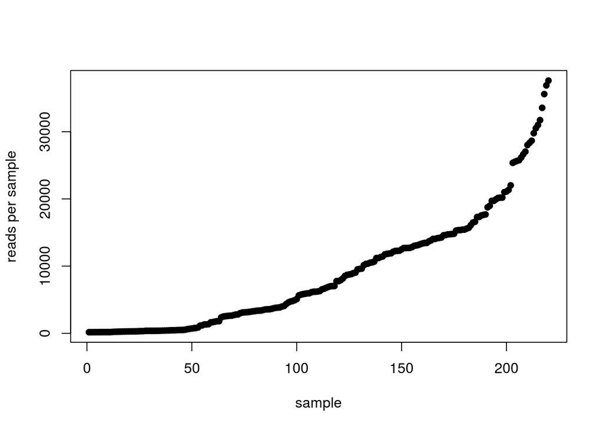

# 2) Normalization to 167 reads per sample

Let’s normalize the original dataset by randomly subsampling 167 reads in each station:

```r
library(vegan)
tp_vp_16SmiTags_c_v2_t<-t(tp_vp_16SmiTags_c_v2)
tp_16mt_c_ss167<-rrarefy(tp_vp_16SmiTags_c_v2_t, 167)
```

The normalized table shows the following dimensions and format:

```
## [1]  220 2101
```

```
##        OTU_1 OTU_2 OTU_3 OTU_4 OTU_5
## MP0310     0     0     0     0     0
## MP0311     0     0     0     0     0
## MP0319     1     0     0     0     0
## MP0321     0     0     0     0     0
## MP0323     0     0     0     0     0
```

Its content fits with the expected normalization values (167 reads per station):

```r
rowSums(tp_16mt_c_ss167)
```

```
##            MP0310            MP0311            MP0319            MP0321
##               167               167               167               167
##            MP0323            MP0528            MP0778            MP0786
##               167               167               167               167
##            MP0888            MP1104            MP1174            MP1176
##               167               167               167               167
##            MP1387            MP1417            MP1421            MP1455
##               167               167               167               167
##            MP1517            MP1527            MP1529            MP1671
##               167               167               167               167
##            MP1672            MP1680            MP1683            MP1684
##               167               167               167               167
##            MP1855            MP1857            MP2239            MP2241
##               167               167               167               167
##            MP2243            MP2376            MP2813            MP2815
##               167               167               167               167
##            MP2819            MP2821             MP581             MP860
##               167               167               167               167
##    X100_DCM_0d2.3    X100_MES_0d2.3    X100_SUR_0d2.3    X102_DCM_0d2.3
##               167               167               167               167
##    X102_MES_0d2.3    X102_SUR_0d2.3    X109_DCM_0d2.3    X109_MES_0d2.3
##               167               167               167               167
##    X109_SUR_0d2.3    X110_DCM_0d2.3    X110_MES_0d2.3    X110_SUR_0d2.3
##               167               167               167               167
##    X111_DCM_0d2.3    X111_MES_0d2.3    X111_SUR_0d2.3    X112_DCM_0d2.3
##               167               167               167               167
##    X112_MES_0d2.3    X112_SUR_0d2.3  X122_DCM_0d1.0d2 X122_DCM_0d2.0d45
##               167               167               167               167
##    X122_DCM_0d2.3 X122_DCM_0d45.0d8  X122_MES_0d1.0d2 X122_MES_0d2.0d45
##               167               167               167               167
##    X122_MES_0d2.3 X122_MES_0d45.0d8  X122_SUR_0d1.0d2 X122_SUR_0d2.0d45
##               167               167               167               167
##    X122_SUR_0d2.3 X122_SUR_0d45.0d8 X123_DCM_0d2.0d45    X123_DCM_0d2.3
##               167               167               167               167
## X123_DCM_0d45.0d8 X123_SUR_0d2.0d45    X123_SUR_0d2.3 X123_SUR_0d45.0d8
##               167               167               167               167
##  X124_DCM_0d1.0d2    X124_DCM_0d2.3 X124_DCM_0d45.0d8  X124_SUR_0d1.0d2
##               167               167               167               167
##    X124_SUR_0d2.3 X124_SUR_0d45.0d8 X125_DCM_0d2.0d45    X125_DCM_0d2.3
##               167               167               167               167
```

[output cut: 55 more lines]

```
##               167               167               167               167
##  X76_MES_0d45.0d8  X76_SUR_0d2.0d45     X76_SUR_0d2.3  X76_SUR_0d45.0d8
##               167               167               167               167
##  X78_DCM_0d2.0d45     X78_DCM_0d2.3  X78_DCM_0d45.0d8     X78_MES_0d2.3
##               167               167               167               167
##  X78_MES_0d45.0d8  X78_SUR_0d2.0d45     X78_SUR_0d2.3  X78_SUR_0d45.0d8
##               167               167               167               167
##    X7_DCM_0d2.1d6     X82_DCM_0d2.3     X82_SUR_0d2.3     X84_SUR_0d2.3
##               167               167               167               167
##     X85_DCM_0d2.3     X85_MES_0d2.3     X85_SUR_0d2.3     X93_DCM_0d2.3
##               167               167               167               167
##     X94_SUR_0d2.3     X96_SUR_0d2.3     X98_DCM_0d2.3     X98_MES_0d2.3
##               167               167               167               167
##     X98_SUR_0d2.3     X99_SUR_0d2.3    X9_DCM_0d2.1d6    X9_SUR_0d2.1d6
##               167               167               167               167
```

Let’s check out how many OTUs don’t appear in the new table:

```r
length(which(colSums(tp_16mt_c_ss167)==0))
```

```
## [1] 970
```

There are 970 OTUs that don’t show any occurrence in the normalized data. Let’s remove them from the table and take a look at its final dimensions:

```r
tp_16mt_c_ss167_no_cero<-tp_16mt_c_ss167[,-(which(colSums(tp_16mt_c_ss167)==0))]
dim(tp_16mt_c_ss167_no_cero)
```

```
## [1]  220 1131
```

Datasets summary:

tp_vp_16SmiTags_c_v2_t –> 220 2101

tp_16mt_c_ss167_no_cero –> 220 1131

# 3) General community analysis

## 3.1) Richness and evenness (Shannon index)

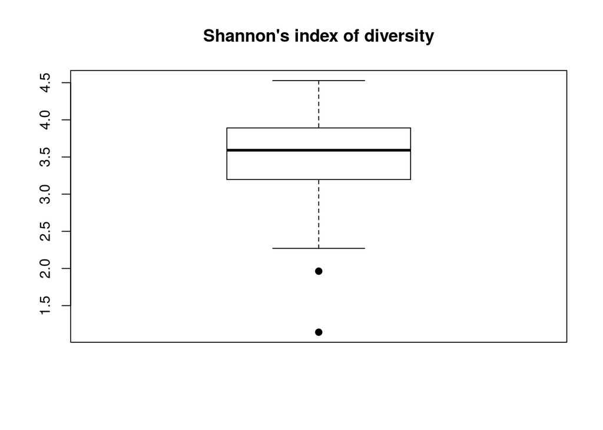

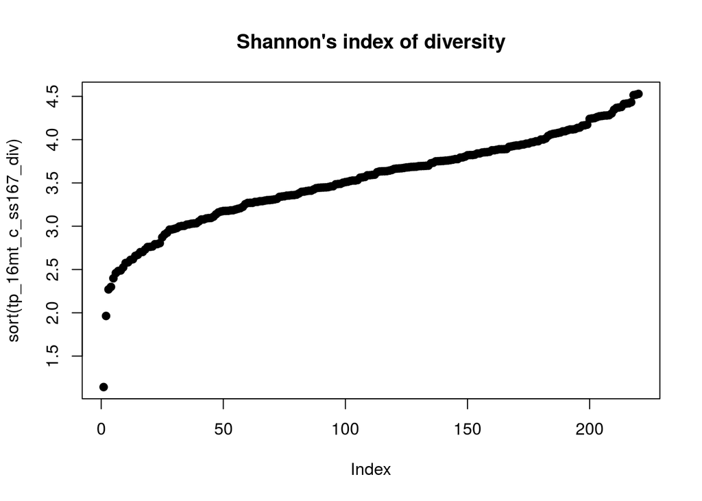

## 3.2) Richness: OTU number

Lowest number of OTUs per sample:

```
## [1] 23
```

Maximum number of OTUs per sample:

```
## [1] 113
```

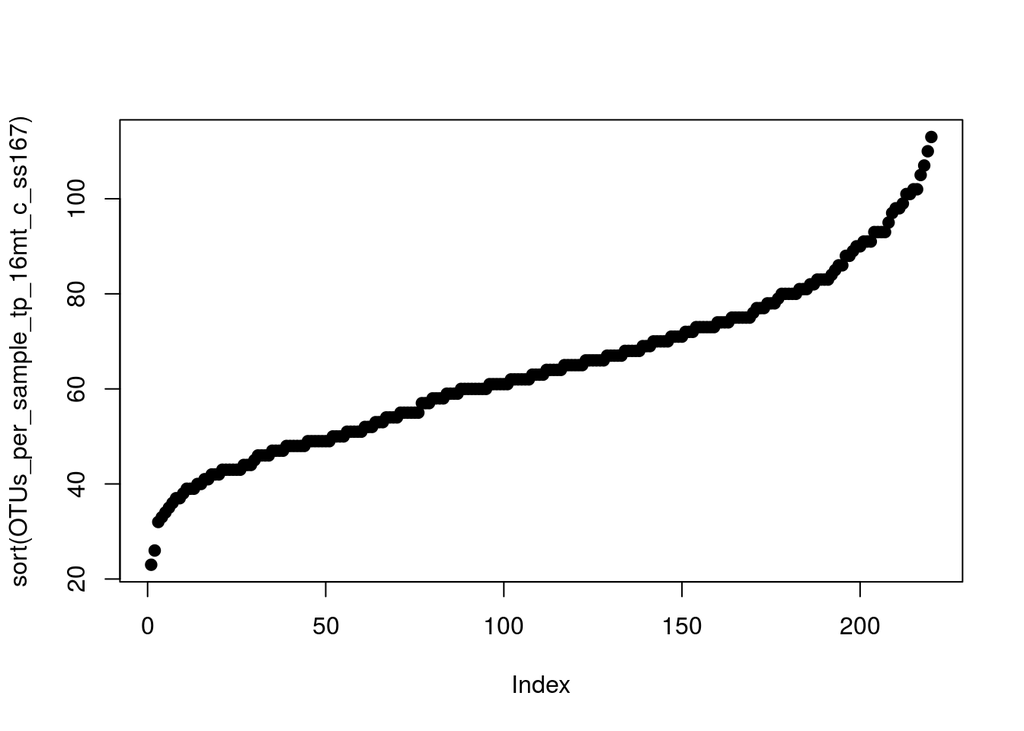

```r
plot(sort(OTUs_per_sample_tp_16mt_c_ss167), pch=19)
```

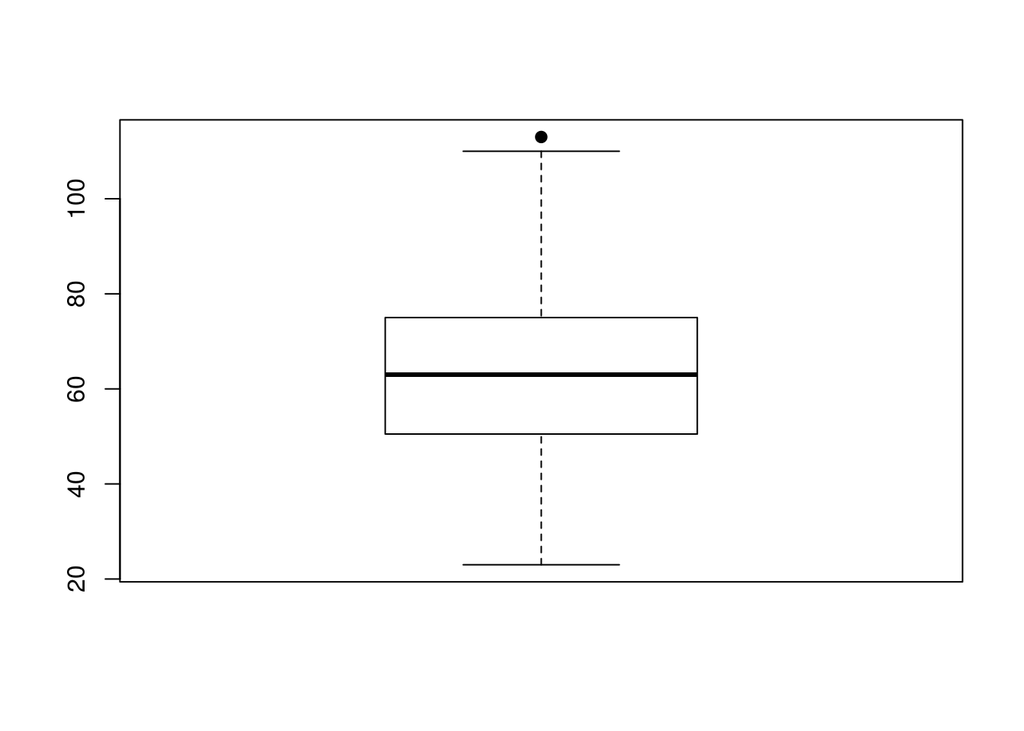

```r
boxplot(OTUs_per_sample_tp_16mt_c_ss167, pch=19)
```

## 3.3) Index of evenness

### 3.3.1) Pielou’s index

```r
pielou_c_venness_tp_16mt_c_ss167 <- tp_16mt_c_ss167_div/log(OTUs_per_sample_tp_16mt_c_ss167)
```

The Pielou index (constrained between 0 and 1) takes values closer to 1 as the variation of species proportion in a sample decreases. Most of our samples get values between 0.8 and 0.9, meaning that the numerical composition of different OTUs within our samples is so similar:

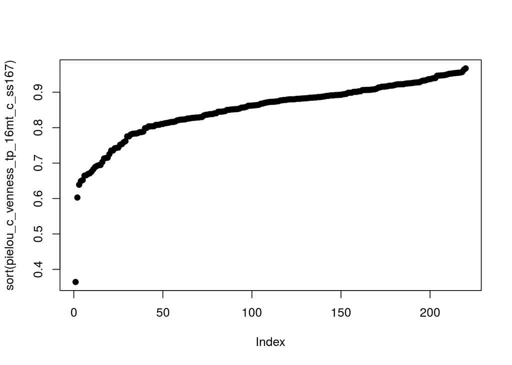

```r
plot(sort(pielou_c_venness_tp_16mt_c_ss167), pch=19)
```

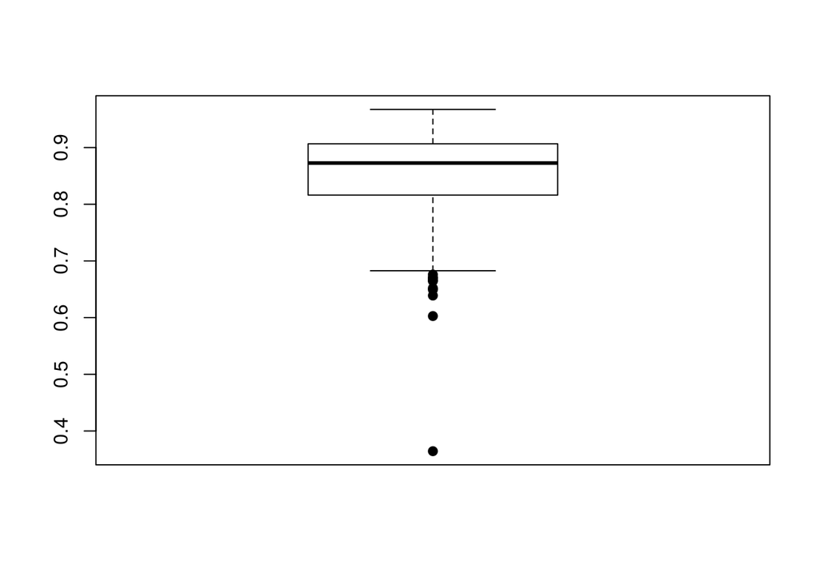

```r
boxplot(pielou_c_venness_tp_16mt_c_ss167, pch=19)
```

The OTU_1417, with 2383 reads, is the most abundant in the overall dataset:

```r
head(sort(colSums(tp_16mt_c_ss167_no_cero), decreasing=T), n=10L)
```

```
## OTU_1417 OTU_1414 OTU_1404 OTU_1408 OTU_1405   OTU_72 OTU_1416 OTU_1481
##     2383     1549     1265     1107      869      844      826      814
## OTU_1456    OTU_1
##      747      659
```

Most of the OTUs show few occurrences:

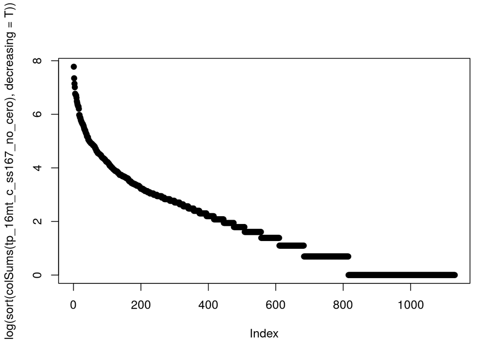

```r
plot(log(sort(colSums(tp_16mt_c_ss167_no_cero), decreasing=T)), pch=19)
```

## 3.4) Abundance Models

### 3.4.2) Preston’s Lognormal Model

According to Preston’s lognormal model fit into species frequencies groups, we’re missing ~1557 species:

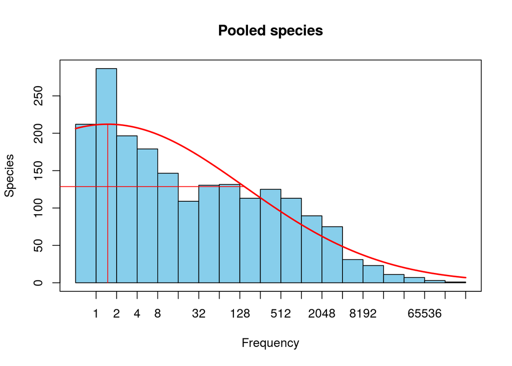

```r
tp_16mt_c_ss167_prestonfit<-prestonfit(colSums(tp_vp_16SmiTags_c_v2_t))
plot(tp_16mt_c_ss167_prestonfit, main="Pooled species")
```

```r
veiledspec(tp_16mt_c_ss167_prestonfit)
```

```
## Extrapolated     Observed       Veiled
##     3540.205     1983.000     1557.205
```

When computing Preston’s lognormal model fit without pooling data into groups, we seem to miss ~1166 species:

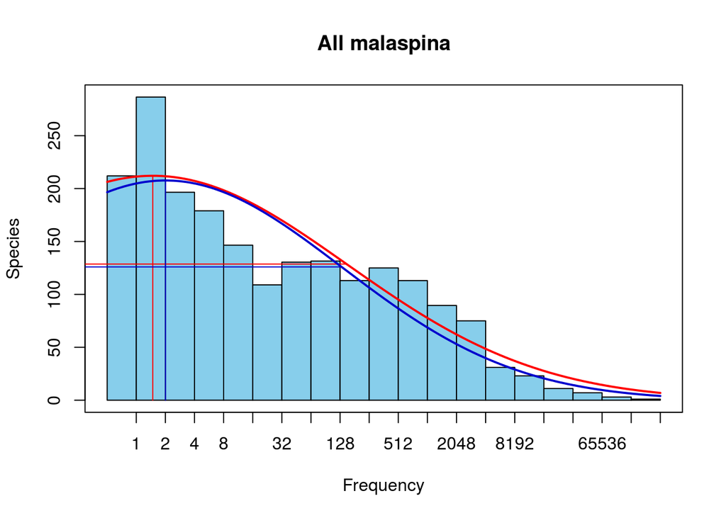

```
## Extrapolated     Observed       Veiled
##       3148.7       1983.0       1165.7
```

## 3.6) Beta diversity

### 3.6.1) Dissimilarity matrix using Bray-Curtis index:

The Bray-Curtis dissimilarity, constrained between 0 (minimum distance) and 1 (highest dissimilarity) allows us to quantify the differences between samples according to the composition and relative abundance of their OTUs. In our dataset, most of the samples pairs take dissimilarity values between 0.7 and 0.9, meaning that their composition is substantially different.

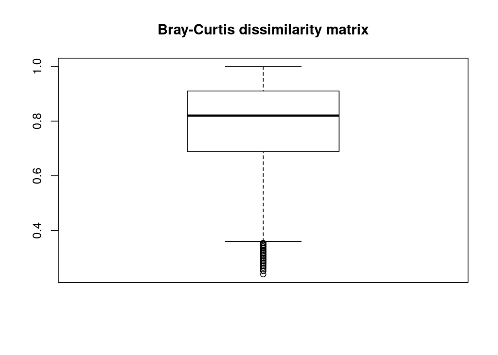

### 3.6.2) Hierarchical clustering

We do observe distinguished clusters; we’ll need to implement further analysis to determine if the observed groups are meaningful.

(To be done: add Longhurst provinces and sampling depth information)

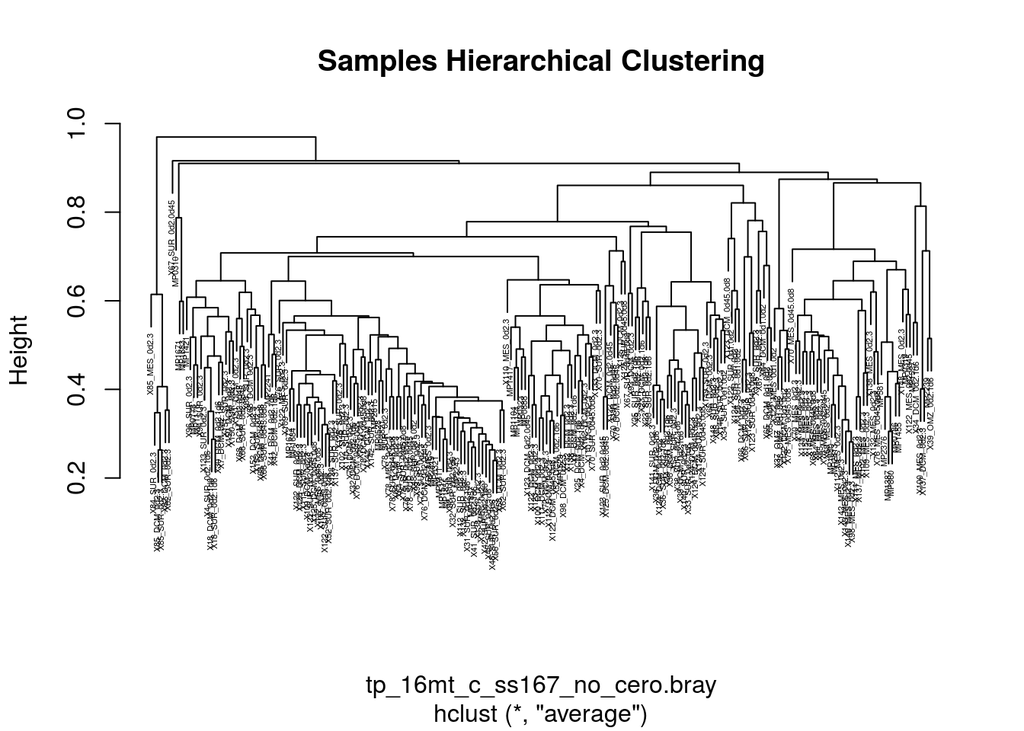

### 3.6.3) Non-metric multidimensional scaling

In general terms, we can distinguish a big cluster in the middle of the chart and even a weak group clustering in the middle-right side of the edge.

The stress parameter takes a value below 0.3, meaning that the plot is valid.

```
##
## Call:
## monoMDS(dist = tp_16mt_c_ss167_no_cero.bray)
##
## Non-metric Multidimensional Scaling
##
## 220 points, dissimilarity 'bray', call 'vegdist(x = tp_16mt_c_ss167_no_cero, method = "bray")'
##
## Dimensions: 2
## Stress:     0.2242055
## Stress type 1, weak ties
## Scores scaled to unit root mean square, rotated to principal components
## Stopped after 111 iterations: Stress nearly unchanged (ratio > sratmax)
```

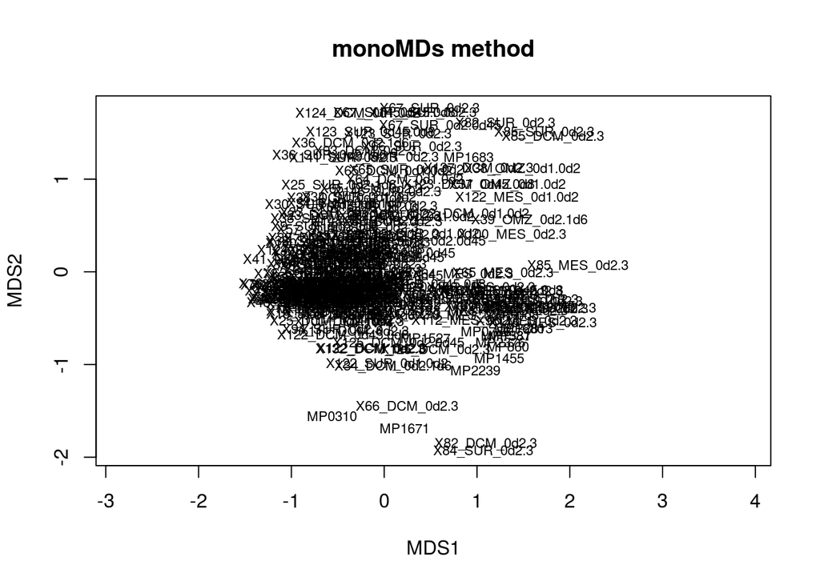

When implementing a most robut function for computing NMDS plots, the result is quiet the same:

```
## ... procrustes: rmse 0.03213479  max resid 0.1588329
## ... procrustes: rmse 0.01890405  max resid 0.1482379
```

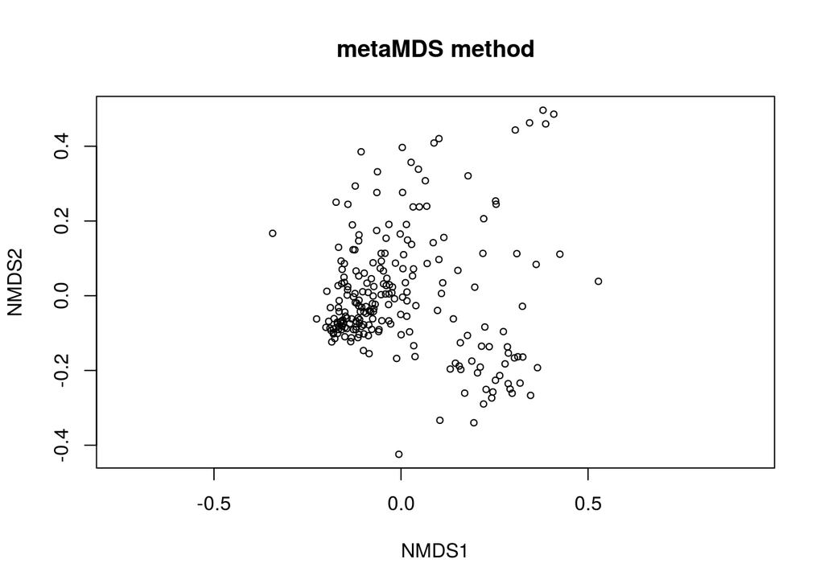

# 4) Geographical analysis

Working datasets:

1. Community matrix: tp_16mt_c_ss167_no_cero

```r
dim(tp_16mt_c_ss167_no_cero)
```

```
## [1]  220 1131
```

```r
tp_16mt_c_ss167_no_cero[1:5, 1:5]
```

```
##        OTU_1 OTU_2 OTU_3 OTU_6 OTU_8
## MP0310     0     0     0     0     0
## MP0311     0     0     0     0     0
## MP0319     1     0     0     0     2
## MP0321     0     0     0     0     0
## MP0323     0     0     0     0     0
```

```r
tp_16mt_c_ss167_no_cero.bray<-as.matrix(tp_16mt_c_ss167_no_cero.bray)
```

3. Stations distances in km: geo_distances_TP_16S_c_ss167

```r
dim(geo_distances_TP_16S_c_ss167)
```

```
## [1] 220 220
```

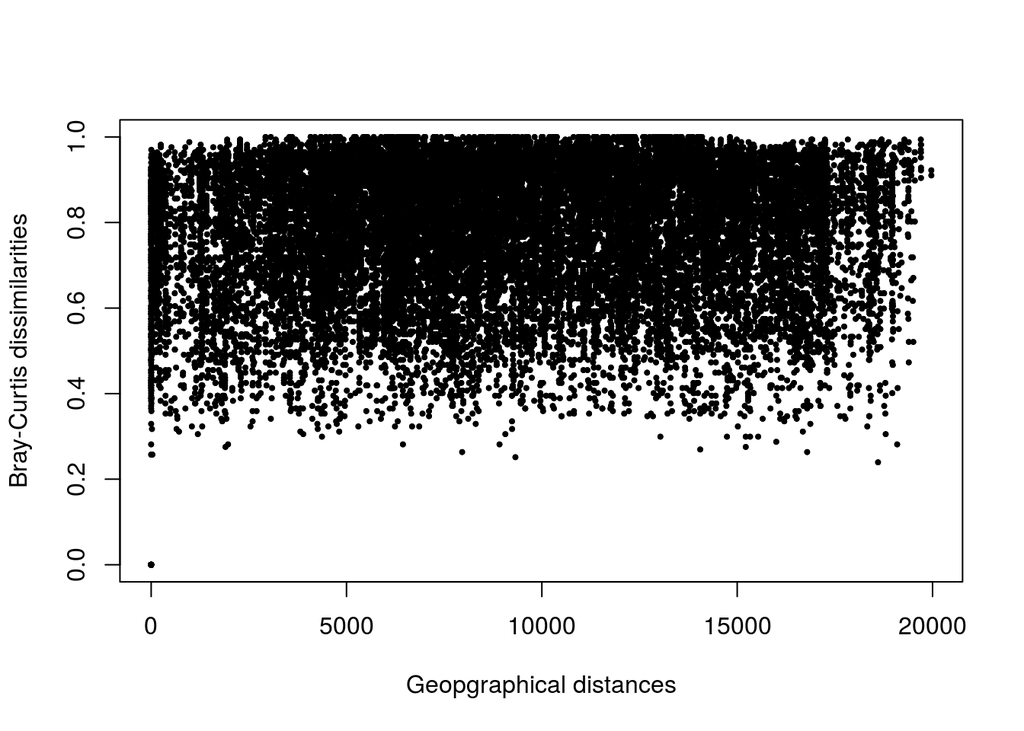

```r
plot(geo_distances_TP_16S_c_ss167, tp_16mt_c_ss167_no_cero.bray, pch=19, cex=0.4, xlab="Geopgraphical distances", ylab="Bray-Curtis dissimilarities")
```

## 4.1) Mantel correlograms

The Mantel Test statistic is significant, but it is that low that it’s difficult to appreciate the evolution of the correlation in the correlograms.

```r
mantel(geo_distances_TP_16S_c_ss167, tp_16mt_c_ss167_no_cero.bray)
```

```
##
## Mantel statistic based on Pearson's product-moment correlation
##
## Call:
## mantel(xdis = geo_distances_TP_16S_c_ss167, ydis = tp_16mt_c_ss167_no_cero.bray)
##
## Mantel statistic r: 0.04862
##       Significance: 0.002
##
## Upper quantiles of permutations (null model):
##    90%    95%  97.5%    99%
## 0.0193 0.0257 0.0315 0.0366
## Permutation: free
## Number of permutations: 999
```

Maximum distance between samples:

```
## [1] 19969.22
```

Minimum distance between samples:

```
## [1] 0
```

Correlograms:

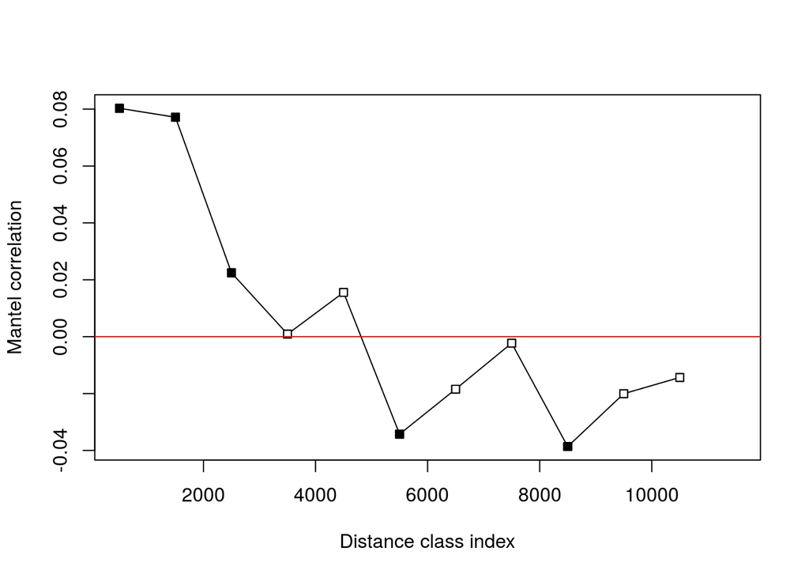

```r
TP_16S_c_ss167_mantel_correl_by_1000km<-mantel.correlog(tp_16mt_c_ss167_no_cero.bray, D.geo=geo_distances_TP_16S_c_ss167, break.pts=seq(0,20000, by=1000))
plot(TP_16S_c_ss167_mantel_correl_by_1000km)
```

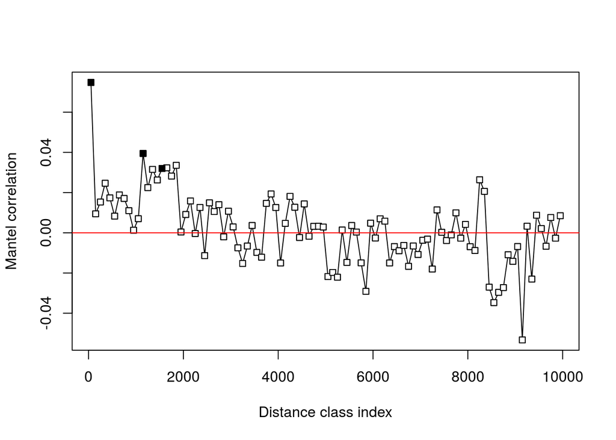

```r
TP_16S_c_ss167_mantel_correl_by_100km<-mantel.correlog(tp_16mt_c_ss167_no_cero.bray, D.geo=geo_distances_TP_16S_c_ss167, break.pts=seq(0,20000, by=100))
plot(TP_16S_c_ss167_mantel_correl_by_100km)
```

# 5) Abundance & occurence

In the following plot, we can appreciate the OTUs distribution according to their percentage of occurence and relative abundance. The red line keeps up OTUs that occur in more than 80% of the samples, whereas the blue line restricts regionally abundant OTUs (> 0.1%).

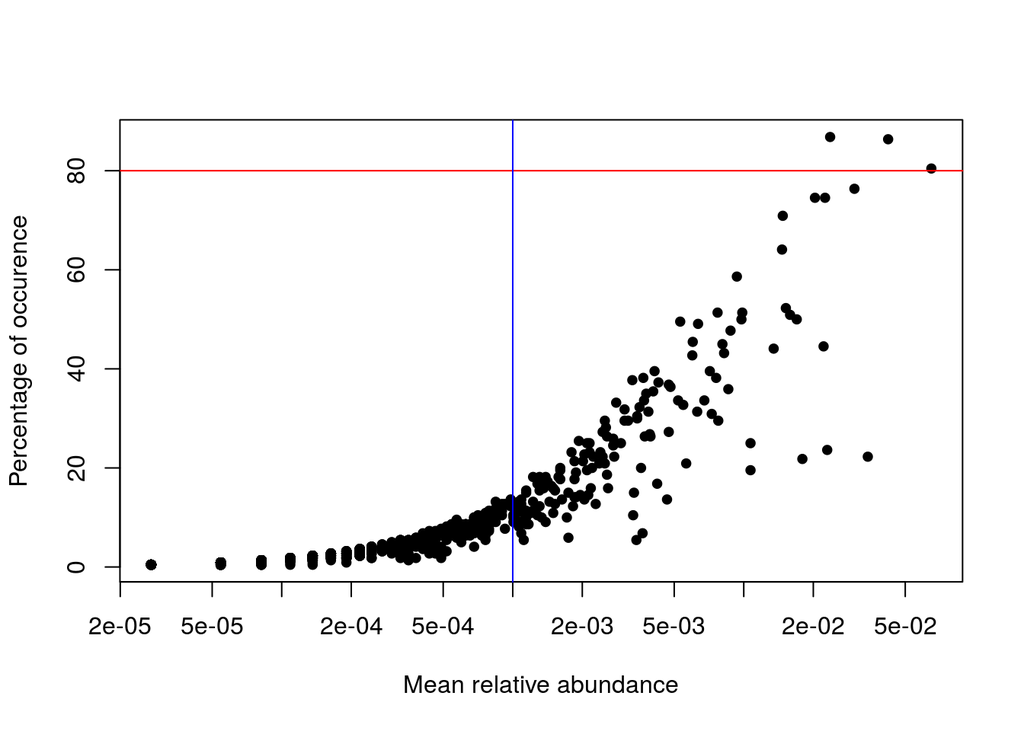

Regionally abundant OTUs (relative abundance over 0.1%):

```
##          mean_rabund perc_occur
## OTU_1417 0.064861187  80.454545
## OTU_1414 0.042161132  86.363636
## OTU_1404 0.034431138  22.272727
## OTU_1408 0.030130648  76.363636
## OTU_1405 0.023652695  86.818182
## OTU_72   0.022972237  23.636364
## OTU_1416 0.022482308  74.545455
## OTU_1481 0.022155689  44.545455
## OTU_1456 0.020332063  74.545455
## OTU_1    0.017936854  21.818182
## OTU_1432 0.016956995  50.000000
## OTU_1435 0.015868263  50.909091
## OTU_1483 0.015215024  52.272727
## OTU_1463 0.014752314  70.909091
## OTU_1460 0.014643440  64.090909
## OTU_1521 0.013473054  44.090909
## OTU_1487 0.010696788  19.545455
## OTU_260  0.010696788  25.000000
## OTU_17   0.009853021  51.363636
## OTU_1406 0.009771366  50.000000
## OTU_1426 0.009335874  58.636364
## OTU_1452 0.008764290  47.727273
## OTU_1543 0.008573762  35.909091
## OTU_1517 0.008219924  43.181818
## OTU_1475 0.008083832  45.000000
## OTU_152  0.007757213  29.545455
## OTU_1431 0.007702776  51.363636
## OTU_1560 0.007593903  38.181818
## OTU_1527 0.007267284  30.909091
## OTU_1571 0.007131192  39.545455
## OTU_1470 0.006750136  33.636364
## OTU_1441 0.006341862  49.090909
## OTU_1486 0.006287425  31.363636
## OTU_1465 0.006015242  45.454545
## OTU_233  0.005988024  42.727273
## OTU_1523 0.005634186  20.909091
## OTU_1448 0.005470876  32.727273
## OTU_15   0.005307567  49.545455
## OTU_1425 0.005198694  33.636364
```

[output cut: 107 more lines]

```
## OTU_1522 0.001088732  12.272727
## OTU_367  0.001088732   9.090909
## OTU_174  0.001088732   6.818182
## OTU_1436 0.001061513  13.181818
## OTU_304  0.001061513  13.181818
## OTU_349  0.001061513   8.181818
## OTU_67   0.001061513  11.363636
## OTU_1557 0.001034295  11.818182
## OTU_1619 0.001034295  10.909091
## OTU_331  0.001034295   9.545455
## OTU_101  0.001007077  12.272727
## OTU_26   0.001007077  10.454545
## OTU_313  0.001007077  10.454545
## OTU_1956 0.001007077  10.000000
## OTU_362  0.001007077   9.090909
```

```r
dim(tp_16mt_c_ss167_abundant_sorted)
```

```
## [1] 161   2
```

Proportion of regionally abundant OTUs (%):

```
## [1] 14.23519
```

Cosmopolitan OTUs (abundance over 0.1% and occurence in more than 80% of samples):

```
##          mean_rabund perc_occur
## OTU_1405  0.02365269   86.81818
## OTU_1414  0.04216113   86.36364
## OTU_1417  0.06486119   80.45455
```

```r
dim(tp_16mt_c_ss167_cosmop_sorted)
```

```
## [1] 3 2
```

Proportion of cosmopolitan OTUs (%):

```
## [1] 0.265252
```

Number and proportion (%) of rare OTUs:

```r
dim(tp_16mt_c_ss167_rabund_percoccur[tp_16mt_c_ss167_rabund_percoccur$mean_rabund < 0.00001 & tp_16mt_c_ss167_rabund_percoccur$mean_rabund >0,])
```

```
## [1] 0 2
```

```
## [1] 0
```

We can’t identify any instance of rare OTUs (!).